# Practical Lab 3 - Vanilla CNN and Fine-Tune VGG16 - for Dogs and Cats Classification

- Student Name: Tai Siang Huang
- Student ID: 9006413

## Instructions

In this lab, we will work through a common practice of Deep Learning Engineers - that is - take an existing model, that does something similar to what the engineer is interested doing, and fine-tune it for the specific task at-hand. Notice to follow a good notebook structure, and focus on readability and clarity of the code, insights and conclusions.

```python
import os
os.environ['TF_CPP_MIN_LOG_LEVEL'] = '2'  # Suppress TensorFlow warnings

import tensorflow as tf
from tensorflow import keras
from tensorflow.keras import layers
import pathlib
from tensorflow.keras.utils import image_dataset_from_directory
# Metrics
from sklearn.metrics import confusion_matrix, classification_report, precision_recall_curve
import numpy as np

physical_devices = tf.config.list_physical_devices('GPU')
tf.config.experimental.set_memory_growth(physical_devices[0], True)
tf.random.set_seed(42)
np.random.seed(42)
```

## 1. Obtain the Data: Get the Dogs vs Cats dataset (see class' notebook, only 5000, not 25,000, images are required, these image set is defined in the notebook)

```python
data_folder = pathlib.Path('../../data/kaggle_dogs_vs_cats_small')

train_dataset = image_dataset_from_directory(
    data_folder / "train",
    image_size=(180, 180),
    batch_size=32)
validation_dataset = image_dataset_from_directory(
    data_folder / "validation",
    image_size=(180, 180),
    batch_size=32)
test_dataset = image_dataset_from_directory(
    data_folder / "test",
    image_size=(180, 180),
    batch_size=32)
```

```
Found 2000 files belonging to 2 classes.
Found 1000 files belonging to 2 classes.
Found 2000 files belonging to 2 classes.
```

## 2. EDA: Explore the data with relevant graphs, statistics and insights (5 points)

```python
type(train_dataset)
```

```
tensorflow.python.data.ops.prefetch_op._PrefetchDataset
```

```python
# calculate class distribution
def get_class_distribution(dataset):
    class_counts = {}
    for _, lbl in dataset.unbatch():  # unbatch to iterate over individual samples
        label = lbl.numpy()
        if label in class_counts:
            class_counts[label] += 1
        else:
            class_counts[label] = 1
    return class_counts


train_dist = get_class_distribution(train_dataset)
val_dist = get_class_distribution(validation_dataset)
test_dist = get_class_distribution(test_dataset)

print("Training class distribution:", train_dist)
print("Validation class distribution:", val_dist)
print("Test class distribution:", test_dist)
```

```
Training class distribution: {1: 1000, 0: 1000}
Validation class distribution: {1: 500, 0: 500}
Test class distribution: {0: 1000, 1: 1000}
```

```python
for data_batch, labels_batch in train_dataset:
    print("data batch shape:", data_batch.shape)
    print("labels batch shape:", labels_batch.shape)
    break
```

```
data batch shape: (32, 180, 180, 3)
labels batch shape: (32,)
```

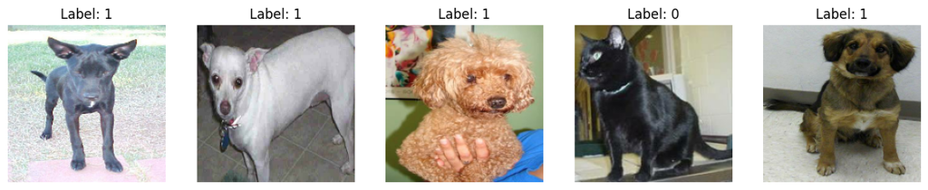

```python
import matplotlib.pyplot as plt

# display 5 images from the training dataset and their labels (0=Cat, 1=Dog)
plt.figure(figsize=(15, 3))
for i in range(5):
    ax = plt.subplot(1, 5, i + 1)
    plt.imshow(data_batch[i].numpy().astype("uint8"))
    plt.title("Label: {}".format(labels_batch[i].numpy()))
    plt.axis("off")
plt.show()
```

## 3. Train two networks (use callbacks to save the best model version):

### 1. Define a Neural Network of your choice (3 points)

```python
# define a CNN model with 5 layer
# use functional API
inputs = keras.Input(shape=(180, 180, 3))
x = layers.Rescaling(1./255)(inputs)
x = layers.Conv2D(32, 3, activation='relu')(x)
x = layers.MaxPooling2D(2)(x)
x = layers.Conv2D(64, 3, activation='relu')(x)
x = layers.MaxPooling2D(2)(x)
x = layers.Conv2D(128, 3, activation='relu')(x)
x = layers.MaxPooling2D(2)(x)
x = layers.Conv2D(256, 3, activation='relu')(x)
x = layers.MaxPooling2D(2)(x)
x = layers.Conv2D(512, 3, activation='relu')(x)
x = layers.MaxPooling2D(2)(x)
x = layers.Flatten()(x) # flatten the output
x = layers.Dense(512, activation='relu')(x) # fully connected layer
x = layers.Dropout(0.5)(x)  # prevent overfitting
outputs = layers.Dense(1, activation='sigmoid')(x)  # binary classification

model = keras.Model(inputs, outputs)

model.summary()
```

```
Model: "functional_23"
```

```
┏━━━━━━━━━━━━━━━━━━━━━━━━━━━━━━━━━┳━━━━━━━━━━━━━━━━━━━━━━━━┳━━━━━━━━━━━━━━━┓
┃ Layer (type)                    ┃ Output Shape           ┃       Param # ┃
┡━━━━━━━━━━━━━━━━━━━━━━━━━━━━━━━━━╇━━━━━━━━━━━━━━━━━━━━━━━━╇━━━━━━━━━━━━━━━┩
│ input_layer_26 (InputLayer)     │ (None, 180, 180, 3)    │             0 │
├─────────────────────────────────┼────────────────────────┼───────────────┤
│ rescaling_16 (Rescaling)        │ (None, 180, 180, 3)    │             0 │
├─────────────────────────────────┼────────────────────────┼───────────────┤
│ conv2d_69 (Conv2D)              │ (None, 178, 178, 32)   │           896 │
├─────────────────────────────────┼────────────────────────┼───────────────┤
│ max_pooling2d_69 (MaxPooling2D) │ (None, 89, 89, 32)     │             0 │
├─────────────────────────────────┼────────────────────────┼───────────────┤
│ conv2d_70 (Conv2D)              │ (None, 87, 87, 64)     │        18,496 │
├─────────────────────────────────┼────────────────────────┼───────────────┤
│ max_pooling2d_70 (MaxPooling2D) │ (None, 43, 43, 64)     │             0 │
├─────────────────────────────────┼────────────────────────┼───────────────┤
│ conv2d_71 (Conv2D)              │ (None, 41, 41, 128)    │        73,856 │
├─────────────────────────────────┼────────────────────────┼───────────────┤
│ max_pooling2d_71 (MaxPooling2D) │ (None, 20, 20, 128)    │             0 │
├─────────────────────────────────┼────────────────────────┼───────────────┤
│ conv2d_72 (Conv2D)              │ (None, 18, 18, 256)    │       295,168 │
├─────────────────────────────────┼────────────────────────┼───────────────┤
│ max_pooling2d_72 (MaxPooling2D) │ (None, 9, 9, 256)      │             0 │
├─────────────────────────────────┼────────────────────────┼───────────────┤
│ conv2d_73 (Conv2D)              │ (None, 7, 7, 512)      │     1,180,160 │
├─────────────────────────────────┼────────────────────────┼───────────────┤
│ max_pooling2d_73 (MaxPooling2D) │ (None, 3, 3, 512)      │             0 │
├─────────────────────────────────┼────────────────────────┼───────────────┤
│ flatten_23 (Flatten)            │ (None, 4608)           │             0 │
├─────────────────────────────────┼────────────────────────┼───────────────┤
│ dense_46 (Dense)                │ (None, 512)            │     2,359,808 │
├─────────────────────────────────┼────────────────────────┼───────────────┤
│ dropout_23 (Dropout)            │ (None, 512)            │             0 │
├─────────────────────────────────┼────────────────────────┼───────────────┤
│ dense_47 (Dense)                │ (None, 1)              │           513 │
└─────────────────────────────────┴────────────────────────┴───────────────┘
```

```
 Total params: 3,928,897 (14.99 MB)
```

```
 Trainable params: 3,928,897 (14.99 MB)
```

```
 Non-trainable params: 0 (0.00 B)
```

```python
model.compile(loss='binary_crossentropy', optimizer='rmsprop', metrics=['accuracy'])

# callback to save the best model
callbacks = [
    keras.callbacks.ModelCheckpoint(
        filepath="./models/best_model_with_cnn_5layer.keras",
        save_best_only=True,
        monitor="val_loss")
]

# fit the model
history = model.fit(
    train_dataset,
    epochs=30,
    validation_data=validation_dataset,
    callbacks=callbacks)
```

```
63/63 ━━━━━━━━━━━━━━━━━━━━ 7s 66ms/step - accuracy: 0.5046 - loss: 0.7459 - val_accuracy: 0.5000 - val_loss: 0.6931
63/63 ━━━━━━━━━━━━━━━━━━━━ 2s 33ms/step - accuracy: 0.5214 - loss: 0.6928 - val_accuracy: 0.5470 - val_loss: 0.6926
63/63 ━━━━━━━━━━━━━━━━━━━━ 2s 33ms/step - accuracy: 0.5233 - loss: 0.6945 - val_accuracy: 0.6150 - val_loss: 0.6909
63/63 ━━━━━━━━━━━━━━━━━━━━ 2s 30ms/step - accuracy: 0.5453 - loss: 0.6922 - val_accuracy: 0.5000 - val_loss: 0.6947
63/63 ━━━━━━━━━━━━━━━━━━━━ 2s 34ms/step - accuracy: 0.5402 - loss: 0.6882 - val_accuracy: 0.5180 - val_loss: 0.6772
63/63 ━━━━━━━━━━━━━━━━━━━━ 2s 33ms/step - accuracy: 0.6043 - loss: 0.6668 - val_accuracy: 0.5720 - val_loss: 0.6610
63/63 ━━━━━━━━━━━━━━━━━━━━ 2s 32ms/step - accuracy: 0.6396 - loss: 0.6365 - val_accuracy: 0.6950 - val_loss: 0.6074
63/63 ━━━━━━━━━━━━━━━━━━━━ 2s 28ms/step - accuracy: 0.6860 - loss: 0.6074 - val_accuracy: 0.6640 - val_loss: 0.6106
63/63 ━━━━━━━━━━━━━━━━━━━━ 2s 32ms/step - accuracy: 0.7023 - loss: 0.5837 - val_accuracy: 0.7170 - val_loss: 0.5729
63/63 ━━━━━━━━━━━━━━━━━━━━ 2s 29ms/step - accuracy: 0.7021 - loss: 0.5631 - val_accuracy: 0.7060 - val_loss: 0.5907
63/63 ━━━━━━━━━━━━━━━━━━━━ 2s 28ms/step - accuracy: 0.7628 - loss: 0.5055 - val_accuracy: 0.6670 - val_loss: 0.6120
63/63 ━━━━━━━━━━━━━━━━━━━━ 2s 28ms/step - accuracy: 0.7643 - loss: 0.4780 - val_accuracy: 0.6560 - val_loss: 0.7740
63/63 ━━━━━━━━━━━━━━━━━━━━ 2s 30ms/step - accuracy: 0.7720 - loss: 0.4855 - val_accuracy: 0.7240 - val_loss: 0.6086
63/63 ━━━━━━━━━━━━━━━━━━━━ 2s 30ms/step - accuracy: 0.8322 - loss: 0.3549 - val_accuracy: 0.7190 - val_loss: 0.7078
63/63 ━━━━━━━━━━━━━━━━━━━━ 2s 30ms/step - accuracy: 0.8635 - loss: 0.3069 - val_accuracy: 0.7480 - val_loss: 0.6450
63/63 ━━━━━━━━━━━━━━━━━━━━ 2s 30ms/step - accuracy: 0.9066 - loss: 0.2017 - val_accuracy: 0.7010 - val_loss: 0.9237
63/63 ━━━━━━━━━━━━━━━━━━━━ 2s 31ms/step - accuracy: 0.9291 - loss: 0.1827 - val_accuracy: 0.7390 - val_loss: 0.9465
63/63 ━━━━━━━━━━━━━━━━━━━━ 2s 30ms/step - accuracy: 0.9470 - loss: 0.1392 - val_accuracy: 0.7320 - val_loss: 1.1022
63/63 ━━━━━━━━━━━━━━━━━━━━ 2s 30ms/step - accuracy: 0.9582 - loss: 0.1260 - val_accuracy: 0.6870 - val_loss: 1.6340
63/63 ━━━━━━━━━━━━━━━━━━━━ 2s 29ms/step - accuracy: 0.9636 - loss: 0.1120 - val_accuracy: 0.7480 - val_loss: 1.2143
63/63 ━━━━━━━━━━━━━━━━━━━━ 2s 30ms/step - accuracy: 0.9547 - loss: 0.1395 - val_accuracy: 0.7410 - val_loss: 1.2166
63/63 ━━━━━━━━━━━━━━━━━━━━ 2s 31ms/step - accuracy: 0.9843 - loss: 0.0641 - val_accuracy: 0.7600 - val_loss: 1.2484
63/63 ━━━━━━━━━━━━━━━━━━━━ 2s 31ms/step - accuracy: 0.9701 - loss: 0.0733 - val_accuracy: 0.7200 - val_loss: 1.6405
63/63 ━━━━━━━━━━━━━━━━━━━━ 2s 30ms/step - accuracy: 0.9702 - loss: 0.1107 - val_accuracy: 0.7400 - val_loss: 1.2729
63/63 ━━━━━━━━━━━━━━━━━━━━ 2s 31ms/step - accuracy: 0.9896 - loss: 0.0374 - val_accuracy: 0.7450 - val_loss: 1.5497
63/63 ━━━━━━━━━━━━━━━━━━━━ 2s 29ms/step - accuracy: 0.9763 - loss: 0.0682 - val_accuracy: 0.6970 - val_loss: 2.3336
63/63 ━━━━━━━━━━━━━━━━━━━━ 2s 34ms/step - accuracy: 0.9807 - loss: 0.0817 - val_accuracy: 0.6490 - val_loss: 2.8027
63/63 ━━━━━━━━━━━━━━━━━━━━ 2s 30ms/step - accuracy: 0.9728 - loss: 0.1028 - val_accuracy: 0.6910 - val_loss: 2.4610
63/63 ━━━━━━━━━━━━━━━━━━━━ 2s 30ms/step - accuracy: 0.9754 - loss: 0.0938 - val_accuracy: 0.7290 - val_loss: 1.7147
63/63 ━━━━━━━━━━━━━━━━━━━━ 2s 32ms/step - accuracy: 0.9913 - loss: 0.0295 - val_accuracy: 0.7410 - val_loss: 1.7833
```